# ‘In a Perishing Condition’: The Fate of Black Inmates in the Philadelphia Almshouse, 1796-1803

Jessica Foster

May 5, 2023

On December 2, 1800, the Philadelphia Almshouse admitted Sarah Bordley and her five-year-old daughter Ann. Born into slavery in Cecil County, Maryland, Sarah had been manumitted upon the death of her master, Robert Thompson. Like thousands of other newly freed slaves, Sarah migrated north to Philadelphia, which had become known as “a center of abolitionism and benevolence toward free blacks.”[^1] Life in a northern city, however, brought a new set of difficulties, especially for formerly enslaved individuals lacking urban skills, formal education, and stable health. According to her own account, recorded by the almshouse clerk, Sarah worked in Philadelphia for two years as “a Washerwoman” to support herself and Ann, until “pains through all her limbs” made it impossible for her to earn a living. By the time Sarah and her daughter sought shelter in the almshouse, they both “were in a perishing condition.”[^2]

Sarah and Ann Bordley were not the only free blacks who spent time in the Philadelphia Almshouse during this period. Of a sample of 1400 individuals admitted between 1796 and 1803, one hundred and thirty-three, or 9.5 percent, were described by the almshouse clerk as “black” (see graph below).[^3] These numbers indicate only a slight overrepresentation: blacks (free and enslaved) made up 9.2 percent of the population of Philadelphia in 1800.[^4]

Scholars such as Gary B. Nash have pointed to the small percentage of black inmates in the almshouse as an indication of the relative success of black Philadelphians “in securing employment and launching independent businesses,” especially when compared to Irish immigrants.[^5] While most poor blacks avoided a stay in the almshouse, a closer look at the data reveals that those who did apply for relief suffered a much higher percentage of deaths than other inmates. Based on a quantitative study of inmate outcomes, I argue that, for many poor blacks, the Philadelphia Almshouse was not a shelter but a place of death: the last stop in a long road of struggle against poverty, disease, and racism.

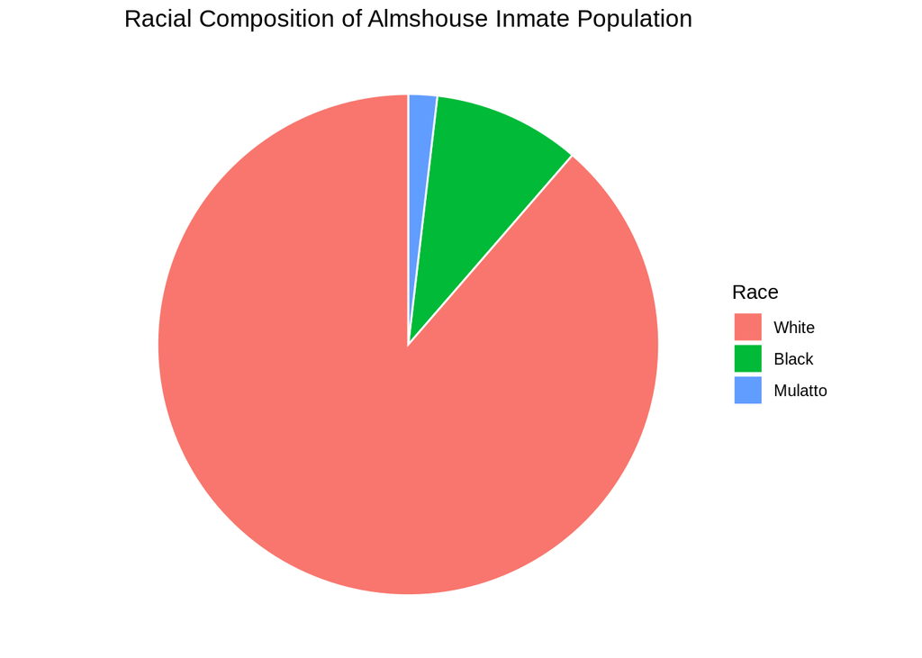

The Philadelphia legislature established a new city almshouse in 1766 in response to the financial crisis brought about by the Seven Years’ War (1756-1763). According to the overseers of Philadelphia’s poor, the number of residents receiving public aid doubled between 1755 and 1764, but the existing poor tax system could not support them. The overseers believed that a “house of employment,” in which the able-bodied poor labored for their livelihood, would be a “more humane and yet less costly” solution.[^6]

People could apply for admission to the almshouse with proof of legal residency and “a signed order from one of the Guardians of the Poor attesting to their impoverished circumstances and their ‘deserving character.’” In the “Daily Occurrence Docket,” the almshouse clerk wrote a description of each person admitted and “noted which official had signed the admission order. The clerk also debited or credited the admission or discharge of inmates to their legal place of residence.”[^7]

In addition to making notes on admitted inmates, the almshouse clerk also noted the reasons why inmates left the almshouse. As the barplot below shows, almost half of all inmates (48.5 percent) were simply “discharged.” Less than one fifth (18.7 percent) died. Over 13 percent “eloped,” i.e., left the almshouse without permission. Approximately 10 percent were bound out as indentured servants. About 7.9 percent do not have a reason for discharge indicated. A very small percentage were sent to the hospital or jail.

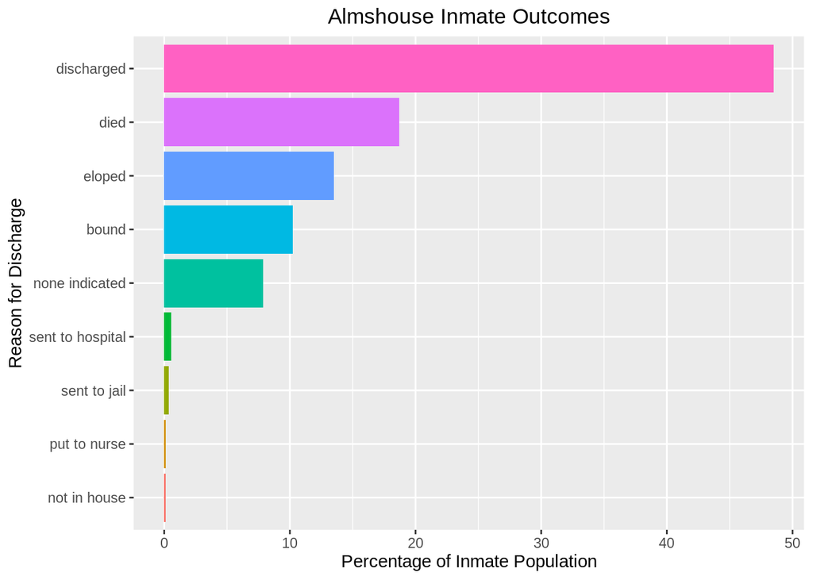

We can break down the outcomes further by grouping the inmates into categories: inmates with a listed gender of male or female; inmates described as “child”, “foundling”, or “born”; inmates described as “black”; and inmates described as “irish”.

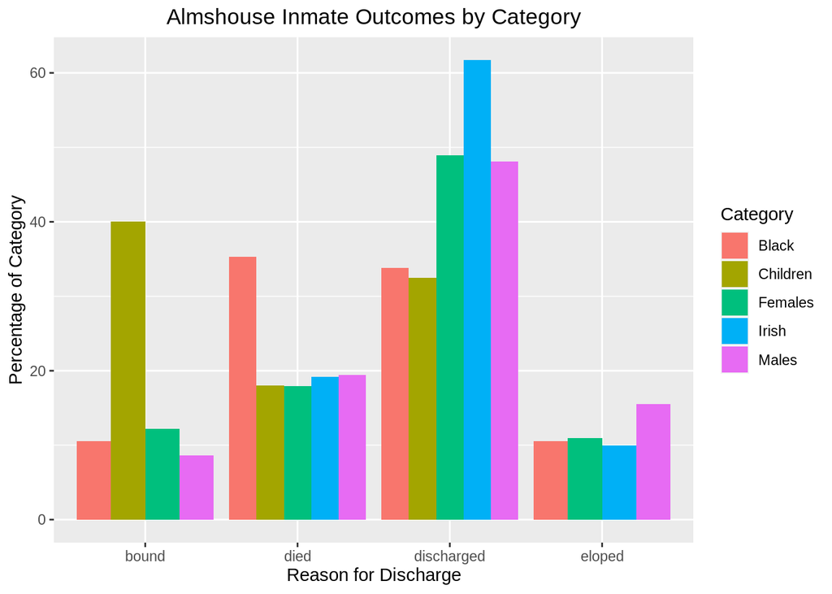

On the surface, these outcomes do not present any surprises. The percentages of those who died are similar for most inmate groups. The high percentage of “bound” children reflects the common practice of indenturing boys and girls to local families. Irish immigrants had a much higher discharge rate (61.7 percent), which accords with the fact that they did not stay long in the almshouse (less than three months on average).

However, the outcomes for black inmates require more explanation. While only 18.7 percent of all inmates died, over one third (35.3 percent) of black inmates perished in the almshouse. The percentage is even higher (37.1 percent) when inmates described as “mulatto” are added. Only a third of black inmates were discharged, while 10.5 percent eloped or were bound out as indentured servants.

Without information on the causes of death of the inmates or the mortality rates for poor blacks and whites in Philadelphia, both of which are beyond the scope of this project, it is difficult to know why such a large percentage of black inmates died in the almshouse. However, we can make some educated guesses.

First of all, as Billy G. Smith notes, Philadelphia’s poor “usually applied for admission to the almshouse only after appealing for help from all other sources,” including family, friends, and the community. “Many indigents avoided the institution because it functioned less as a refuge and more as a prison where officials tried to control the poor and to shape their morals.”[^8] This delay in seeking admission, coupled with high morbidity rates among the poor, meant that many people arrived at the almshouse already in debilitated condition. Yet less than one fifth of admittees died. This alone does not explain the high percentage of deaths among black inmates.

While poor blacks were susceptible to many of the same diseases and ailments as poor whites and immigrants, many of them had the additional burden of a past life in slavery. As Gary B. Nash notes, black migrants to Philadelphia often arrived with “broken families, poor health, and psychological disorientation.”[^9] Racial discrimination also forced blacks to perform the most menial and punishing work. For the men, this meant “loading ships, digging wells, graves, and house foundations, and toiling as sawyers, sweepers, porters, ashmen, chimney sweeps, and bootblacks.”[^10] For black women like Sarah Bordley, it meant “cooking, cleaning homes, caring for children, and washing clothes for whites.”[^11] Thus, many poor blacks arrived at the almshouse suffering not only from the trauma of enslavement, but also from “[u]nending toil, exhaustion, malnutrition, and inferior clothing and shelter.”[^12] To give but one example: James Breahere was born a slave in Marcus Hook, Pennsylvania. Manumitted in 1783, he moved to Philadelphia, where he worked as a laborer for twelve years before the “hard work, and frequent colds, which has fell into his limbs…rendered [him] unable to support himself by any kind of Work.” Admitted to the almshouse on November 6, 1800, James died the following month.[^13]

If slavery and hard labor worsened the condition of poor blacks before they reached the almshouse, we must also ask whether the treatment they received inside the house contributed to their high death percentage. Until the 1820s, the Philadelphia Almshouse was not racially segregated. In fact, there was little segregation at all except by sex. As Priscilla Ferguson Clement notes, the concept of inmate classification was still new at the turn of the nineteenth century, and “welfare officials in Philadelphia and elsewhere had little inclination to segregate inmates in any rigorous fashion. New arrivals were simply assigned to whatever beds were currently vacant on the men’s or women’s side of the almshouse.”[^14] While “raving lunatics, severely ill people, pregnant women, aged married couples, and orphaned children” were assigned to specialized wards, “diversity prevailed” in the rest of the almshouse.[^15]

It seems that, in theory at least, black inmates did not receive different treatment based on their race. However, we know that the guardians of the poor, who managed the almshouse, discriminated against different kinds of poor people. They believed that the almshouse should be reserved for the “better sort of poor”, while the so-called “vicious” poor should be sent to the county workhouse.[^16] This philosophy of poor relief had tangible effects on the inmates. Those individuals deemed idle or disorderly had their allowance of meat, sugar, and tea limited or withheld entirely. They were also likely to be confined to one of the cells or to the “black hole”.[^17] Given Philadelphians’ increasingly negative views of blacks as idle, immoral, and rebellious, it is not difficult to imagine that black inmates could inadvertently fall afoul of the almshouse staff or their fellow inmates who prepared and distributed the food, watched the cells, and nursed the ill.[^18] Considering the poor condition in which many of them arrived, even minor discrimination in food or medicine could mean the difference between life and death.

Sarah Bordley and her daughter Ann were fortunate. The girl was bound out a week after admission, likely to a white family, as was the custom. Sarah needed more time to recover; she was discharged from the almshouse a few months later in March.

### Bibliography

Alexander, John K. *Render Them Submissive: Responses to Poverty in Philadelphia, 1760-1800*. Amherst: University of Massachusetts Press, 1980.

Clement, Priscilla F. *Welfare and the Poor in the Nineteenth-Century City: Philadelphia, 1800–1854*. Rutherford, NJ: Fairleigh Dickinson University Press, 1985.

Nash, Gary B. *Forging Freedom: The Formation of Philadelphia’s Black Community, 1720-1840*. Cambridge, MA: Harvard University Press, 1988. Ebook. https://hdl-handle-net.libproxy.clemson.edu/2027/heb01388.0001.001.

Smith, Billy G. “Almshouse Admissions Philadelhia 1796-1803.” March 4, 2020. Distributed by University of Pennsylvania McNeil Center for Early American Studies. https://repository.upenn.edu/mead/42/.

Smith, Billy G. *Life in Early Philadelphia: Documents from the Revolutionary and Early National Periods*. University Park, PA: Pennsylvania State University Press, 1995.

Smith, Billy G. *The “Lower Sort”: Philadelphia’s Laboring People, 1750-1800*. Ithaca, NY: Cornell University Press, 1990.

Smith, Billy G., and Cynthia Shelton. “THE DAILY OCCURRENCE DOCKET OF THE PHILADELPHIA ALMSHOUSE: SELECTED ENTRIES, 1800–1804.” *Pennsylvania History: A Journal of Mid-Atlantic Studies* 52, no. 3 (July 1985): 183-205. https://www.jstor.org/stable/27773054.

[^1]: Gary B. Nash, *Forging Freedom: The Formation of Philadelphia’s Black Community, 1720-1840* (Cambridge, MA: Harvard University Press, 1988), 137, Ebook, https://hdl-handle-net.libproxy.clemson.edu/2027/heb01388.0001.001.
[^2]: Billy G. Smith and Cynthia Shelton, “THE DAILY OCCURRENCE DOCKET OF THE PHILADELPHIA ALMSHOUSE: SELECTED ENTRIES, 1800–1804,” *Pennsylvania History: A Journal of Mid-Atlantic Studies* 52, no. 3 (July 1985): 192, https://www.jstor.org/stable/27773054. See also Billy G. Smith, *The “Lower Sort”: Philadelphia’s Laboring People, 1750-1800* (Ithaca, NY: Cornell University Press, 1990), 196.
[^3]: Billy G. Smith, “Almshouse Admissions Philadelhia 1796-1803” (March 4, 2020), distributed by University of Pennsylvania McNeil Center for Early American Studies, https://repository.upenn.edu/mead/42/. Smith created this sample from a microfilm of the Index of Admissions to the Philadelphia Almshouse housed in the Philadelphia City Archives. This sample, taken from the years 1796-1803, includes last names A through G, as well as a small number of “black” and “mulatto” individuals without last names.
[^4]: Nash, *Forging Freedom*, 143.
[^5]: Nash, *Forging Freedom*, 154, 155-156.
[^6]: John K. Alexander, *Render Them Submissive: Responses to Poverty in Philadelphia, 1760-1800* (Amherst: University of Massachusetts Press, 1980), 88-89; Billy G. Smith, *Life in Early Philadelphia: Documents from the Revolutionary and Early National Periods* (University Park, PA: Pennsylvania State University Press, 1995), 30.
[^7]: Smith, *Life in Early Philadelphia*, 35-36.
[^8]: Smith, *Life in Early Philadelphia*, 36; Smith, *The “Lower Sort”*, 166.
[^9]: Nash, *Forging Freedom*, 173.
[^10]: Nash, *Forging Freedom*, 145-146.
[^11]: Smith, *The “Lower Sort”*, 195-196.
[^12]: Smith, *The “Lower Sort”*, 55. See also Nash, *Forging Freedom*, 155.
[^13]: Smith and Shelton, “DAILY OCCURRENCE DOCKET”, 189. See also Smith, *The “Lower Sort”*, 55.
[^14]: Priscilla F. Clement, *Welfare and the Poor in the Nineteenth-Century City: Philadelphia, 1800–1854* (Rutherford, NJ: Fairleigh Dickinson University Press, 1985), 85, 86.
[^15]: Clement, *Welfare and the Poor*, 85.
[^16]: Alexander, *Render Them Submissive*, 116, 51-52.
[^17]: Alexander, *Render Them Submissive*, 116, 119; Smith, *Life in Early Philadelphia*, 36.
[^18]: On inmate segregation within and maintenance of the almshouse, see Clement, *Welfare and the Poor*, 87-88. On rising tensions between whites and blacks in Philadelphia during the late eighteenth and early nineteenth centuries, see Nash, *Forging Freedom*, 173-174, 179, 180-181, 272.